# **realPSD**: Getting Started

Feiyu Zhu, Martin Lysy

2021-02-08

In this tutorial, you will learn how to quickly implement a simple Ornstein-Uhlenbeck (OU) process and fit its power spectral density (PSD) in R by using **realPSD** package. A basic understanding of C++ and object-oriented programming is preferred but not mandatory. You will be able to build your own model as long as you follow the instructions given in this vignette. For those who want to get themselves familiar with some C++ concepts, there are many great free tutorials online, for example [this one](https://www.geeksforgeeks.org/c-plus-plus/). For advanced users, if you are insterested in the design and theory behind **realPSD**, please check out the advanced tutorial [online](http://htmlpreview.github.io/?https://github.com/mlysy/realPSD/blob/master/doc/realPSD-advancedtut.html) or from within R with the command `vignette("realPSD-advancedtut")`.

# Model Setup

## Ornstein-Uhlenbeck Process

A simple OU model without the additional drift term is given by the stochastic differential equation (SDE)
$$\mathrm{d}X_t = -\alpha X_t \mathrm{d}t + \beta \mathrm{d}B_t$$
where $\alpha > 0$ and $\beta > 0$ and $B_t$ denotes Brownian motion (or Wiener process). If we assume $X_0 \sim {\mathcal N}(0, \beta^2/2\alpha)$, then $X_t$ is a stationary, zero-mean Gaussian process with autocovariance function
$$\gamma(t) = \frac{\beta^2}{(2\alpha)} \cdot e^{-\alpha |t|}$$
The power spectral density (PSD) is the Fourier transform of $\gamma(t)$
$$\operatorname{\mathcal S}_X(f) = {\mathcal F}\{\gamma(t)\} = \frac{\beta^2}{\alpha^2 + (2\pi f)^2}.$$
where $f$ is the frequency in Hertz (Hz).

In R, we can define a function to calculate the theoretical PSD.

```r
#' PSD for the OU model.
#'
#' @param freq Vector of frequencies
#' @param alpha Mean reversion parameter.
#' @param beta Scale parameter.
#' @return PSD vector at the frequencies in `freq`.
ou_psd <- function(freq, alpha, beta) {
  beta^2/((2*pi*freq)^2 + alpha^2)
}
```

## Parameter Basis

In **realPSD**, we use $\theta$ to represent the parameter vector in the “inferential” basis which is what we can read directly from the model, i.e. $\theta = (\alpha, \beta)$ for the OU model. On the other hand, in the “computational” basis, we use $\log$ transformed parameters to help the optimization under unconstrained scale, i.e. $\phi = \log(\alpha)$ and $\zeta = \log(\beta^2) = 2\log(\beta)$ in the OU example. We will later see the difference between the two.

## Simulation

**realPSD** provides a handy function `ou_sim` to generate the exact OU process. Note the simulation is exact since we are not using Euler approximation. This is only the case for the OU process. To simulate more general and complicated SDEs, approximation is inevitable. For that purpose, the R package [**msde**](https://CRAN.R-project.org/package=msde) is the state-of-the-art tool you would like to use.

```r
# true parameter values
theta0 <- c(alpha = 3.1, beta = 2.2)

# timescale for simulation
frange <- c(1e-4, 1e2) # frequency range
fs <- frange[2]*2 # sampling frequency
dt <- 1/fs # interobservation time
N <- floor(fs/frange[1]) # number of observations

# time domain simulation
set.seed(314159) # just for reproducibility
Xt <- ou_sim(gamma = theta0[1], mu = 0, sigma = theta0[2], dt = dt, n_obs = N)
```

## Empirical vs Theoretical PSD Trajectories

We can clearly see that the simulation was successful in that the empirical PSD overlaps with the theoretical PSD curve.

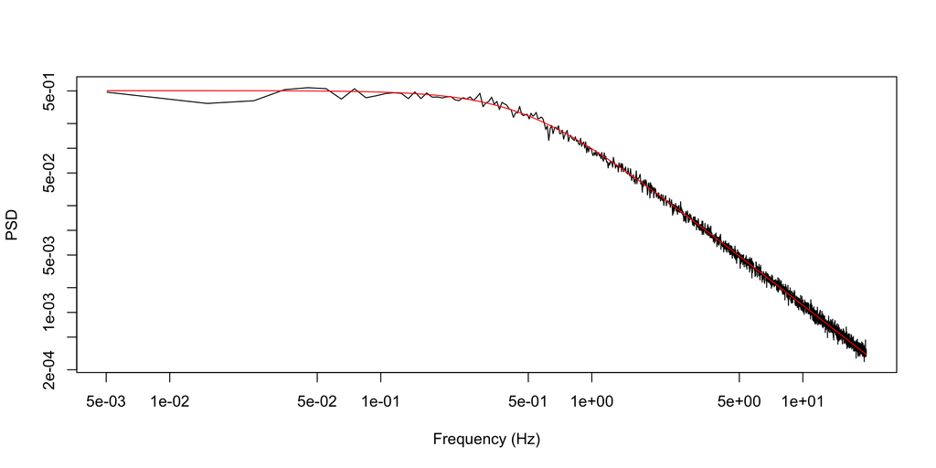

```r
psd_emp <- periodogram(Xt, fs = fs)
psd_emp <- psd_emp %>% filter(freq < 20)
bin_size <- 100 # for estimation and plotting
psd_bin <- as.data.frame(lapply(psd_emp, binning,
                                bin_size = bin_size, bin_type = "mean"))

plot(psd_bin$freq, psd_bin$Ypsd, type = "l", log = "xy",
     xlab = "Frequency (Hz)", ylab = "PSD")
curve(ou_psd(freq = x, alpha = theta0[1], beta = theta0[2]),
      col = "red", add = TRUE)
```

# Create the OU Model Object

## Write the OU model Header File in C++

To provide efficient estimation for general parametric PSD models, **realPSD** requires you to write your own model in a standalone C++ header file (with extension `.hpp`). The file has been written for you and put in the Appendix for your reference.

Basically, we defined a `UFun` class within our own namespace `ou` to avoid any potential scope conflict with the **realPSD** package. Later whenever we refer to this class, we will use `ou::UFun` to emphasize its namespace. The `ou::UFun` class is nothing fancy but just a collection of necessary data and functions we need to evaluate the PSD of the OU process. In our specific example, we need to provide

- the length of the simulated time series `N` and frequencies `f` which are supplied via the constructor `UFun::UFun(cRefMatrix<Type>&f)` (inside the constructor `set_f()` is called to set internally `N_ = f.size()`);
- a public method `UFun::eval()` to evaluate the PSD.

Consider the definition of `UFun::eval()` method

```cpp
/// @param[out] U Normalized PSD vector of size `N`.
/// @param[in] phi Computational basis parameters.  Here we have `phi = log(alpha)`.
template <class Type>
inline void UFun<Type>::eval(RefMatrix<Type> U, cRefMatrix<Type>& phi) {
  U = (scale_ * f2_).array() + exp(Type(2.0)*phi(0,0));
  U = U.array().inverse();
  return;
}
```

you will notice it is basically the C++ translation of the R function `ou_psd()`. The only difference is about normalization. We write the PSD as $S(f) = \beta^2 U(f)$ where
$$U(f) = \frac{1}{(2\pi f)^2 + \alpha^2}$$
is the normalized PSD we are using in **realPSD**.

The private members `f_`, `f2_` and `scale_` can be understood as some intermediary variables to help us create the method `UFun::eval()` eventually. But we don’t need them to be accessed outside of the class `ou::UFun`, so they are private. These variables are by no means mandatory but just for convenience. You should think about how to create your own private members based on your specific model.

As for `RefMatrix<Type>` and `cRefMatrix<Type>`, they are pre-defined data types used by **realPSD** to help users make use of data types in the C++ [Eigen](http://eigen.tuxfamily.org/index.php?title=Main_Page) library. Just make sure you have the line `#include "realPSD/utils.hpp"` at the beginning of your header file. Then the compiler will automatically include the utility tools provided by **realPSD** to facilitate your job. In `realPSD/utils.hpp`, we defined

```cpp
/// Typedef equivalent to `Ref <MatrixXd<Type> >`.
template <class Type>
using RefMatrix = Eigen::Ref <Eigen::Matrix<Type, Eigen::Dynamic, Eigen::Dynamic> >;
/// Typedef equivalent to `const Ref <const MatrixXd<Type> >`
template <class Type>
using cRefMatrix = const Eigen::Ref <const Eigen::Matrix<Type, Eigen::Dynamic, Eigen::Dynamic> >;
```

You can understand both `RefMatrix<Type>` and `cRefMatrix<Type>` simply as built-in data types for matrix. But the difference is that `RefMatrix<Type>` should be used for something we need to make changes to whereas `cRefMatrix<Type>` should be used for some constants we don’t change. A `const` keyword in C++ basically means a “promise” that we will not make any changes. That is why we declared

```cpp
/// Evaluate the normalized PSD.
  void eval(RefMatrix<Type> U, cRefMatrix<Type>& phi);
```

in which `RefMatrix<Type> U` is used for storing the value of the normalized PSD and may potentially be changed, thus it is [passed by value](https://www.educative.io/edpresso/pass-by-value-vs-pass-by-reference) whereas `cRefMatrix<Type>& phi` is used for pointing to the parameters elsewhere and is [passed by reference](https://www.educative.io/edpresso/pass-by-value-vs-pass-by-reference) (notice the `&` in `cRefMatrix<Type>&`) since we don’t need to change the parameters inside `UFun::eval()`. This distinction makes the code more efficient since we don’t have to hard-copy the constant objects everytime we call `UFun::eval()`. Similarly, we also have `RefVector` and `cRefVector` for vector data types in `realPSD/utils.hpp`.

```cpp
/// Typedef equivalent to `Ref <VectorXd<Type> >`.
template <class Type>
using RefVector = Eigen::Ref <Eigen::Matrix<Type, Eigen::Dynamic, 1> >;
/// Typedef equivalent to `const Ref <const VectorXd<Type> >`
template <class Type>
using cRefVector = const Eigen::Ref <const Eigen::Matrix<Type, Eigen::Dynamic, 1> >;
```

Besides, users are free to use `zero_matrix<Type>(int n, int p)` to initialize an `nxp` matrix with zeros, which is another useful tool given in `realPSD/utils.hpp`.

```cpp
/// Create `matrix<Type>` of zeros.
///
/// @param[in] n Integer number of rows.
/// @param[in] p Integer number of columns.
/// @return A `matrix<Type>` of size `n x p` initialized with zeros.
template<class Type>
matrix<Type> zero_matrix(int n, int p) {
  matrix<Type> out(n,p);
  out.setZero();
  return out;
}
```

You may notice that we have an overloaded constructor `UFun(cRefMatrix<Type>& f, cRefMatrix<Type>& extra_arg)` and an external constructor `UFun<Type> make_Ufun()` for `ou::UFun` class. The overloaded constructor allows users to get additional data into their model. The external constructor helps you get around some technical issues involved in [**TMB**](https://CRAN.R-project.org/package=TMB). For more details, please see the [advanced tutorial](http://htmlpreview.github.io/?https://github.com/mlysy/realPSD/blob/devel-ferris-prerelease/doc/realPSD-advancedtut.html).

To summarize, you can follow the steps below to create a model header file:

1. Create an empty C++ header file with extension `.hpp` and name it whatever you like. In our example, we name the file `OU_Model.hpp`. Put it under the current working directory.
2. Give a name to your namespace to wrap your model class. Usually the namespace is named according to your model, e.g. `ou` in our example.
3. Create a `ou::UFun` class within your namespace. It is recommended to define the class as a template class in the way as shown in our example, i.e. `template <class Type> class UFun {...};`. It would enable you to make use of the data types given by C++ [Eigen](http://eigen.tuxfamily.org/index.php?title=Main_Page) library.
4. Create necessary public members (variables or functions) to get data from outside and to evaluate your normalized PSD. Think about how to create some private members for internal computation. Usually it is a good idea to make your own constructor (instead of using the default constructor) to initialize some private data members as we did in the example.
5. The rest of the file should be just a simple copy-and-paste of the example header file.

## Compile the OU Model

Now let’s compile the header file and create the `ou_model` object as follows:

**Step 1:** The package **realPSD** uses [**TMB**](https://CRAN.R-project.org/package=TMB) internally for model building and estimation. But you don’t need to learn how to use [**TMB**](https://CRAN.R-project.org/package=TMB) from scratch. **realPSD** provides a wrapper function `make_psd_model` to help you automatically generate a C++ file (called “OU_FitMethods.cpp”) needed by [**TMB**](https://CRAN.R-project.org/package=TMB) to compile the model.

```r
# create c++ file
ou_cpp <- make_psd_model(model = "OU",
                         header = "OU_Model.hpp",
                         class = "ou::UFun",
                         ctor = "ou::make_Ufun",
                         standalone = TRUE)
# write the content into a .cpp file called OU_FitMethods.cpp under your current working directory
cat(ou_cpp, sep = "\n", file = "OU_FitMethods.cpp")
```

**Step 2:** After we have the necessary C++ file `OU_FitMethods.cpp`, we can compile it by using the following code. It will call [**TMB**](https://CRAN.R-project.org/package=TMB) to compile the model object. Just copy and paste the code for your own project. All you need to change is the name of the file.

```r
# compile it
model <- "OU_FitMethods"
TMB::compile(paste0(model, ".cpp"),
             PKG_CXXFLAGS = paste0("-I", system.file("include", package = "realPSD"),
                                   " -std=gnu++11"))
```

```
#> Note: Using Makevars in /Users/feiyuzhu/.R/Makevars
#> [1] 0
```

```r
dyn.load(TMB::dynlib(model))
```

**Step 3:** Finally, we create the OU model R6 class in R to facilitate our later estimation process.

```r
# create the ou_model class
ou_model <- R6::R6Class(
  classname = "ou_model",
  inherit = realPSD::psd_model,
  private = list(
    n_phi_ = 1,
    tmb_model_ = "OU",
    tmb_DLL_ = "OU_FitMethods"
  ),
  public = list(
    #  Method to convert a value of `phi` into `theta` for the OU model
    #' @param theta Value of `phi = log(alpha)`
    #' @param zeta Value of `zeta = 2*log(beta)`
    #' @return Parameter vector of `theta = c(alpha, beta)`
    to_theta = function(phi, zeta) {
      c(alpha = exp(phi), beta = exp(zeta/2))
    },
    # Method to convert a value of natural parameter `theta` into the log transformed parameter `phi_zeta` for the OU model
    #' @param theta Value of `theta = c(alpha, beta)`
    #' @param obj Model object created by `ou_model`
    #' @return List with element `phi` and `zeta`
    to_phi = function(theta) {
      phi <- log(theta[1])
      zeta <- 2*log(theta[2])
      list(phi = phi, zeta = zeta)
    }
  )
)
```

Here `classname` is user-defined and we call it “ou_model”. It will be an object inherit from an existing built-in R6 class object `realPSD::psd_model` provided by **realPSD**, so we set `inherit = realPSD::psd_model`. `tmb_model_` should be the same as the `model` input in `make_psd_model()` and `tmb_DLL_` should be the same as the name of the automatically generated C++ file in the above **Step 1**, i.e. “OU_FitMethods” in our case. We can add public methods specifically for the OU model as shown above. Please note that `to_theta` should be treated as a reserved keyword for converting parameters from their computational basis ($\log$ transformed parameterization $\phi$ and $\zeta$) back to the inferential basis (natural parameterization $\theta$).

For more details about R6 class, please see [here](https://r6.r-lib.org/index.html).

## Testing

To check whether the implementation is correct, we’ll compare the **TMB** implementation of the $U(f, \phi)$ method of `ou_model` to a pure R functional implementation.

```r
# construct the model object
ou_obj <- ou_model$new(freq = psd_emp$freq, Ypsd = psd_emp$Ypsd,
                       bin_size = 100, est_type = "lp")

ou_ufun <- ou_obj$ufun() # TMB method corresponding to UFun.eval()
U_tmb <- ou_ufun$fn(log(theta0[1])) # evaluate at frequencies for lp estimator
# same calculation in R
U_r <- ou_psd(freq = psd_bin$freq, alpha = theta0[1], beta = 1)
# U_r <- ou_psd(freq = psd_emp$freq, alpha = theta0[1], beta = 1) # use this line if est_type = "mle"
range(U_tmb - U_r)
```

```
#> [1] -1.387779e-17  1.387779e-17
```

Note that we used R6 `realPSD::psd_model` class to initialize the OU model object by its public method `ou_model$new()` . Then we used the class method `psd_model$ufun()` to get the normalized PSD. Essentially speaking, `psd_model$ufun()` returns a `TMB::MakeADFun()` object which has its own method `ufun$fn()`, thus we can evaluate the PSD at frequencies for LP estimator as given above.

It is always a good idea to do this kind of tests in the process of building your own model. The R package [**testthat**](https://CRAN.R-project.org/package=testthat) is great for this purpose. For more details about unit tests, please see [here](https://testthat.r-lib.org).

# Parameter Estimation

Now we are ready to fit the OU model by using **realPSD**. Three methods are provided, i.e. maximum likelihood estimation (MLE), log periodogram estimation (LP), non-linear least squares estimation (NLS). The theoretical background of these three methods is summarized in the [advanced tutorial](http://htmlpreview.github.io/?https://github.com/mlysy/realPSD/blob/devel-ferris-prerelease/doc/realPSD-advancedtut.html). More technical details can be found in this preprint.

## MLE

We can fit the OU model using MLE (profile likelihood) as follows:

```r
# instantiate TMB object for profile likelihood
ou_obj$set_est(est_type = "mle")
ou_nlp <- ou_obj$nlp()

opt <- optimize(f = ou_nlp$fn, lower = log(.1), upper = log(10))
mle_fit <- ou_obj$to_est(opt$min, to_theta = FALSE) # estimates in the computational/log-transformed basis
print(mle_fit)
```

```
#> $coef
#>      phi     zeta
#> 1.154226 1.587913
#>
#> $vcov
#>               phi         zeta
#> phi  6.831151e-05 5.329083e-06
#> zeta 5.329083e-06 5.415755e-06
```

```r
mle_est <- ou_obj$to_est(opt$min, to_theta = TRUE) # estimates in the "inferential basis"
print(mle_est)
```

```
#> $coef
#>    alpha     beta
#> 3.171568 2.212132
#>
#> $vcov
#>              alpha         beta
#> alpha 6.871350e-04 1.869423e-05
#> beta  1.869423e-05 6.625537e-06
```

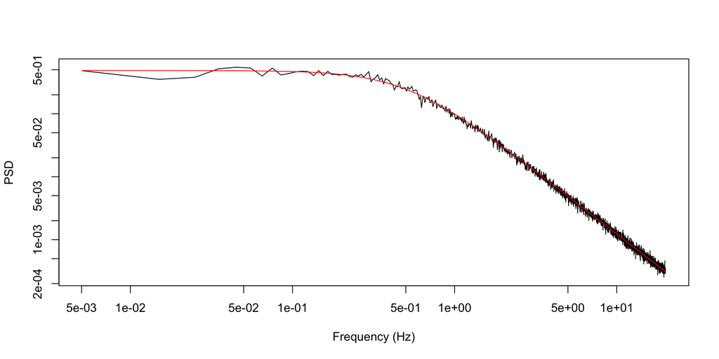

```r
plot(psd_bin$freq, psd_bin$Ypsd, type = "l", log = "xy",
     xlab = "Frequency (Hz)", ylab = "PSD")
curve(ou_psd(freq = x, alpha = exp(mle_fit$coef[1]), beta = exp(mle_fit$coef[2]/2)),
      col = "red", add = TRUE)
```

Let us explain the above code line by line.

1. Instantiate a model object for profile likelihood by using the method `psd_model$set_est()`. It has three arguments:
   - `est_type` which specifies one of the three estimators `lp`, `nls` and `mle`,
   - `bin_size` which is the bin size for frequency compression, by default is set to 100,
   - `bin_type` which specifies one of the two binning type `mean` and `median`.
2. Apply the method `psd_model$nlp()` to construct the negative profile loglikelihood object. Remeber the result is itself an object which has some relevant methods:
   - `nlp$fn(phi)` which allows you to evaluate the likelihood at given parameter `phi` value. There are also many other relevant methods,
   - `nlp$gr(phi)` which gives you the numerical gradient at the given parameter `phi` value,
   - `nlp$he(phi)` which gives you the numerical hessian at the given parameter `phi` value,
   - `nlp$simulate(phi)$zeta` which returns the conditional optimum of `zeta` given `phi`.
3. Apply the built-in `stats::optimize` method to obtain the optimal parameter values `opt`. Here we didn’t supply any gradient-based information, so the optimization method is basically a type of derivative-free line search algorithm in one-dimension by specifying both the lower and upper end points. For more details, please refer to the documentation of `stats::optimize`.
4. Call the method `psd_model$to_est()` with `to_theta = FALSE` (by default) to obtain a list with elements `coef` and `vcov` in the computational basis.
5. Print out the result given in step 4, which helps you see the process more clearly.
6. Call the method `psd_model$to_est()` with `to_theta = TRUE` to obtain another list with elements `coef` and `vcov` in the inferential basis. Please note that in order to get accurate `vcov` in the inferential basis, we have to use sandwich estimator to convert the $\log$ scaled `vcov` instead of just `exp()` the `vcov` in the computational basis. For details, one can check out the source code of `psd_model$vcov()`.
7. Similarly, we can print out the result given in step 6.
8. Plot the empirical PSD based on our simulated data.
9. Add the fitted PSD curve based on the estimates. Note that in our estimation, we used the computational basis (i.e. $\log$ transformed parameters) for numerical purposes, so remember to convert them back to the inferential basis to get the correct curve.

Now we can see that the fitted curve fits the simulated data very well.

## LP

Similarly, we can fit the model using LP method.

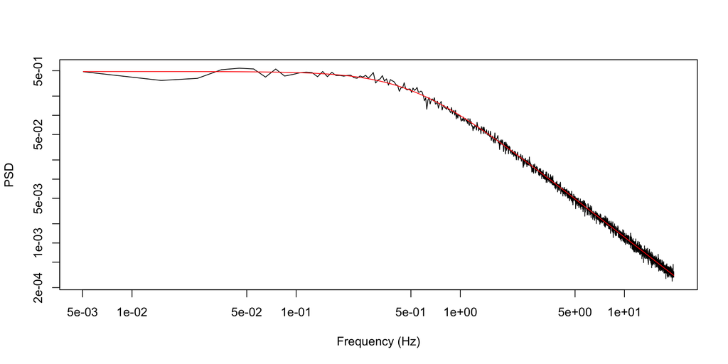

```r
# instantiate TMB object for profile likelihood
ou_obj$set_est(est_type = "lp", bin_size = bin_size)
ou_nlp <- ou_obj$nlp()

opt <- optimize(f = ou_nlp$fn, lower = log(.1), upper = log(10))
lp_fit <- ou_obj$to_est(opt$min) # to_theta = FALSE by default
lp_est <- ou_obj$to_est(opt$min, to_theta = TRUE)

plot(psd_bin$freq, psd_bin$Ypsd, type = "l", log = "xy",
     xlab = "Frequency (Hz)", ylab = "PSD")
curve(ou_psd(freq = x, alpha = exp(lp_fit$coef[1]), beta = exp(lp_fit$coef[2]/2)),
      col = "red", add = TRUE)
```

## NLS

In the same spirit, we can implement the NLS method using the following code.

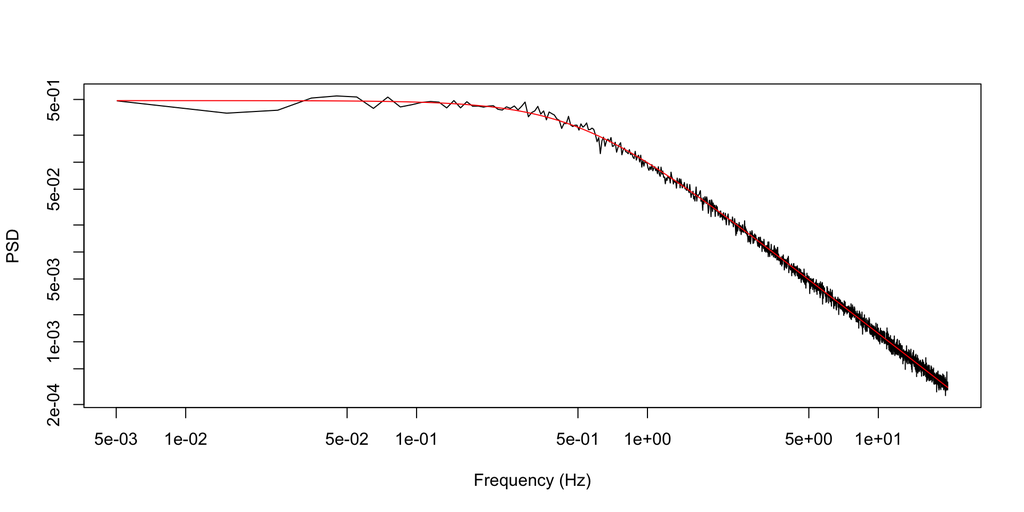

```r
# instantiate TMB object for profile likelihood
ou_obj$set_est(est_type = "nls", bin_size = bin_size)
ou_nlp <- ou_obj$nlp()

opt <- optimize(f = ou_nlp$fn, lower = log(.1), upper = log(10))
nls_fit <- ou_obj$to_est(opt$min)
nls_est <- ou_obj$to_est(opt$min, to_theta = TRUE)

plot(psd_bin$freq, psd_bin$Ypsd, type = "l", log = "xy",
     xlab = "Frequency (Hz)", ylab = "PSD")
curve(ou_psd(freq = x, alpha = exp(lp_fit$coef[1]), beta = exp(lp_fit$coef[2]/2)),
      col = "red", add = TRUE)
```

## Table of Parameter Estimates

Finally, let’s summarize the estimates in the following table for comparison. As we can see, LP gives very close estimates as MLE and the estimator of both methods produced very small standard errors. NLS, on the other hand, gives an estimator with significantly larger standard errors. This result is expected since NLS for the numerical estimation speed, sacrifices the estimation efficiency. That is price we have to pay.

```r
disp <- sapply(list(mle = mle_fit, lp = lp_fit, nls = nls_fit),
               function(fit) c(fit$coef[1], sqrt(fit$vcov[1,1]),
                               fit$coef[2], sqrt(fit$vcov[2,2])))
disp <- cbind(true = c(log(theta0[1]), NA, 2 * log(theta0[2]), NA),
              disp)
disp <- t(disp)
colnames(disp) <- c("phi_est", "phi_se", "zeta_est", "zeta_se")
signif(disp, 3)
```

```
#>      phi_est  phi_se zeta_est zeta_se
#> true    1.13      NA     1.58      NA
#> mle     1.15 0.00827     1.59 0.00233
#> lp      1.16 0.00830     1.59 0.00233
#> nls     1.17 0.02300     1.62 0.02670
```

We can also transform the parameter back to the natural scale (the “inferential basis”), i.e. convert `phi` and `zeta` back to `theta` and output the table.

```r
disp <- sapply(list(mle = mle_est, lp = lp_est, nls = nls_est),
               function(fit) c(fit$coef[1], sqrt(fit$vcov[1,1]),
                               fit$coef[2], sqrt(fit$vcov[2,2])))
disp <- cbind(true = c(theta0[1], NA, theta0[2], NA), disp)
disp <- t(disp)
colnames(disp) <- c("alpha_est", "alpha_se", "beta_est", "beta_se")
signif(disp, 3)
```

```
#>      alpha_est alpha_se beta_est beta_se
#> true      3.10       NA     2.20      NA
#> mle       3.17   0.0262     2.21 0.00257
#> lp        3.17   0.0263     2.21 0.00258
#> nls       3.23   0.0742     2.25 0.03000
```

# Appendix

```cpp
/// @file OU_Model.hpp

#include "realPSD/utils.hpp"

namespace ou {
  using namespace realPSD; // import functions from utils.hpp

  /// The Ornstein-Uhlenbeck model class.
  ///
  /// The PSD of the Ornstein-Uhlenbeck (OU) model is defined as
  ///
  /// \f[
  /// U(f \mid \alpha) = \frac{1}{(2\pi f)^2 + \alpha^2}.
  /// \f]
  /// The parameter is supplied as \f$\phi = \log \alpha\f$.
  template <class Type>
  class UFun {
  private:
    // internal variables
    int N_; ///> problem dimensions
    matrix<Type> f_; ///>column vector of frequencies.
    matrix<Type> f2_; ///> column vector of squared frequencies.
    Type scale_; ///> Scaling factor for frequencies.
    matrix<Type> extra_arg_; ///> Vector of extra arguments
    /// Set frequency vector.
    void set_f(cRefMatrix<Type>& f);
  public:
    /// Constructor.
    UFun(cRefMatrix<Type>& f);
    UFun(cRefMatrix<Type>& f, cRefMatrix<Type>& extra_arg);
    /// Evaluate the normalized PSD.
    void eval(RefMatrix<Type> U, cRefMatrix<Type>& phi);
  };

  /// @param[in] f Frequency vector of size `N`.
  template<class Type>
  inline UFun<Type>::UFun(cRefMatrix<Type>& f) {
    set_f(f); // note that this will also set `N_`
    scale_ = Type(4.0 * EIGEN_PI * EIGEN_PI);
  }

  /// @param[in] f Frequency vector of size `N`.
  /// @param[in] extra_arg Additional argument vector.
  template<class Type>
  inline UFun<Type>::UFun(cRefMatrix<Type>& f, cRefMatrix<Type>& extra_arg) {
    set_f(f); // note that this will also set `N_`
    scale_ = Type(4.0 * EIGEN_PI * EIGEN_PI);
    extra_arg_ = extra_arg; // additional constructor arguments
  }

  /// @param[in] f Frequency vector of size `N`.
  template<class Type>
  inline void UFun<Type>::set_f(cRefMatrix<Type>& f) {
    N_ = f.size();
    f_ = zero_matrix<Type>(N_,1);
    f_ = f;
    f2_ = zero_matrix<Type>(N_,1);
    f2_ = f.cwiseProduct(f);
    return;
  }

  /// @param[out] U Normalized PSD vector of size `N`.
  /// @param[in] phi Computational basis parameters.  Here we have `phi = log(alpha)`.
  template <class Type>
  inline void UFun<Type>::eval(RefMatrix<Type> U, cRefMatrix<Type>& phi) {
    U = (scale_ * f2_).array() + exp(Type(2.0)*phi(0,0));
    // U = exp(Type(2.0)*phi(1,0)) / U.array();
    U = U.array().inverse();
    return;
  }

#undef TMB_OBJECTIVE_PTR
#define TMB_OBJECTIVE_PTR obj
  /// External constructor for `ou::UFun` objects.
  ///
  /// The arguments to this function are always `f` and `obj`.  Inside the function, we can specify additional TMB macros (`DATA_VECTOR`, etc.), to obtain inputs to the `UFun` constructor.
  ///
  /// @param[in] f Frequency vector of size `N`.
  /// @param[in] obj Pointer to the TMB object.
  /// @return An `ou::UFun` object.
  template<class Type>
  UFun<Type> make_Ufun(cRefMatrix<Type>& f, objective_function<Type>* obj) {
    // DATA_MATRIX(extra_arg); // get extra_arg from R
    // return UFun<Type>(f, extra_arg);
    return UFun<Type>(f);
  }
#undef TMB_OBJECTIVE_PTR
#define TMB_OBJECTIVE_PTR this

} // end namespace ou
```